# Understanding Logistic Regression from Scratch

Jun

Feb 12, 2016

## Introduction

In my [last post](http://junma5.weebly.com/data-blog/build-your-own-neural-network-classifier-in-r), we walked through the construction of a two-layer neural network and used it to classify the MNIST dataset. Today, I will show how we can build a logistic regression model from scratch (spoiler: it’s much simpler than a neural network). Linear and logistic regression are probably the simplest yet useful models in a lot of fields. They are fast to implement and also easy to interpret.

In this post, I will first talk about the basics of logistic regression, followed by model construction and training on my [NBA shot log dataset](http://junma5.weebly.com/data-blog/fun-with-advanced-nba-stats), then I will try to interpret the model through statistical inference. Finally, I will compare it with the built-in `glm()` function.

## Logistic regression

Logistic regression is a generalized linear model, with a binominal distribution and logit link function. The outcome $Y$ is either 1 or 0. What we are interested in is the expected values of $Y$, $E(Y)$. In this case, they can also be thought as probability of getting 1, $p$. However, because $p$ is bounded between 0 and 1, it’s hard to implement the method similar to what we did for linear regression. So instead of predicting $p$ directly, we predict the log of odds (logit), which takes values from $-\infty$ to $\infty$. Now the function is: $\log(\frac{p}{1-p})=\theta_0 + \theta_1x_1 + \theta_2x_2 + ...$, let’s denote the RHS as $x\cdot\theta$. Next the task is to find $\theta$.

In logistic regresion, the cost function is defined as: $J=-\frac{1}{m}\sum_{i=1}^m(y^{(i)}\log(h(x^{(i)}))+(1-y^{(i)})\log(1-h(x^{(i)})))$, where $h(x)=\frac{1}{1+e^{-x\cdot\theta}}$ is the sigmoid function, inverse of logit function. We can use gradient descent to find the optimal $\theta$ that minimizes $J$. So this is basically the process to construct the model. It is actually simpler than you think when you starting coding.

## Model construction in R

Now let’s build our logistic regression. First I will define some useful functions. Note `%*%` is the dot product in R.

```r
library(ggplot2)
library(dplyr)
#sigmoid function, inverse of logit
sigmoid <- function(z){1/(1+exp(-z))}

#cost function
cost <- function(theta, X, y){
  m <- length(y) # number of training examples

  h <- sigmoid(X%*%theta)
  J <- (t(-y)%*%log(h)-t(1-y)%*%log(1-h))/m
  J
}

#gradient function
grad <- function(theta, X, y){
  m <- length(y)

  h <- sigmoid(X%*%theta)
  grad <- (t(X)%*%(h - y))/m
  grad
}
```

Here comes the logistic regression fuction, which takes training dataframe X, and label y as function input. It returns a column vector which stores the coefficients in theta. One thing to pay attention to is that the input X usually doesn’t have a bias term, the leading column vector of 1, so I added this column in the function.

```r
logisticReg <- function(X, y){
  #remove NA rows
  temp <- na.omit(cbind(y, X))
  #add bias term and convert to matrix
  X <- mutate(temp[, -1], bias =1)
  X <- as.matrix(X[,c(ncol(X), 1:(ncol(X)-1))])
  y <- as.matrix(temp[, 1])
  #initialize theta
  theta <- matrix(rep(0, ncol(X)), nrow = ncol(X))
  #use the optim function to perform gradient descent
  costOpti <- optim(theta, cost, grad, X=X, y=y)
  #return coefficients
  return(costOpti$par)
}
```

## Training with NBA shot log dataset

Now let’s train our model with the [NBA shot log dataset](http://junma5.weebly.com/data-blog/fun-with-advanced-nba-stats). Specifically, I am interested in how will shot clock, shot distance and defender distance affect shooting performance. Naively, we would think *more time remaining in shot clock, shorter distance to basket, farther to defender* will all increase the probability of a field goal. Shortly, we will see whether we can statistically prove that.

```r
#load the dataset
shot <- read.csv('2014-2015shot.csv', header = T, stringsAsFactors = F)
shot.df <- select(shot, FGM, SHOT_CLOCK, SHOT_DIST, CLOSE_DEF_DIST)
head(shot.df)
```

```
##   FGM SHOT_CLOCK SHOT_DIST CLOSE_DEF_DIST
## 1   1       10.6       6.5            2.1
## 2   0        6.2       4.0            1.9
## 3   1        5.2       2.8            2.2
## 4   1       16.0       8.4            4.4
## 5   1        1.4       4.5            4.4
## 6   0       14.1       1.3            1.9
```

```r
shot.X <- shot.df[, -1]
shot.y <- shot.df[, 1]

mod <- logisticReg(shot.X, shot.y)
mod
```

```
##             [,1]
## [1,] -0.06444830
## [2,]  0.01886594
## [3,] -0.05952669
## [4,]  0.10610004
```

How do we interpret the model?

- The first number is the intercept. It is the log odds of a FG if all other predictors are 0. Note if log odds is 0, the probality is 0.5. So the negative intercept means <50%.
- The next three numbers are the coefficients for SHOT_CLOCK, SHOT_DIST, CLOSE_DEF_DIST. For every unit increase in the predictor, the coefficient is the change of log odds while holding other predictors to be constant.
- For example, let’s look at the last number. While holding others the same, if the defender moves 1 ft farther away, the log odds of that shot will increase by 0.106.
- If the original FG% is 50%, the new FG% will be 52.6% if the defender is 1 ft farther.

Now, look at the signs of the coefficients, we can conclude that increase in SHOT_CLOCK, CLOSE_DEF_DIST and decrease in SHOT_DIST will all have positive impact in FG%.

Next, let’s compare our self-built model with the `glm()` function.

```r
mod1 <- glm(as.factor(FGM) ~ SHOT_CLOCK + SHOT_DIST + CLOSE_DEF_DIST,
            family=binomial(link = "logit"), data=shot.df)

summary(mod1)$coefficients
```

```
##                   Estimate   Std. Error    z value      Pr(>|z|)
## (Intercept)    -0.06663629 0.0144138120  -4.623086  3.780737e-06
## SHOT_CLOCK      0.01889689 0.0008333007  22.677151 7.530998e-114
## SHOT_DIST      -0.05942813 0.0006771956 -87.756216  0.000000e+00
## CLOSE_DEF_DIST  0.10605534 0.0022038402  48.122972  0.000000e+00
```

We did a pretty good job as the coefficient are almost identical to 3rd decimal place.

## Prediction function and the Expected FG%

Finally, I will write a prediction function that will output the probability of getting 1 in a logistic regression.

```r
logisticPred <- function(mod, X){
  X <- na.omit(X)
  #add bias term and convert to matrix
  X <- mutate(X, bias =1)
  X <- as.matrix(X[,c(ncol(X), 1:(ncol(X)-1))])
  return(sigmoid(X%*%mod))
}
```

Generate a new data grid to see how FG% changes with predictors.

```r
newdata <- expand.grid(SHOT_CLOCK = 10,
                       SHOT_DIST = seq(2.5, 37.5, by = 5),
                       CLOSE_DEF_DIST = seq(1, 7, by=2))

FG <- logisticPred(mod, newdata)
```

## Visulize the impact

Shot clock seems to have the least impact, so I will exclude that in this plot.

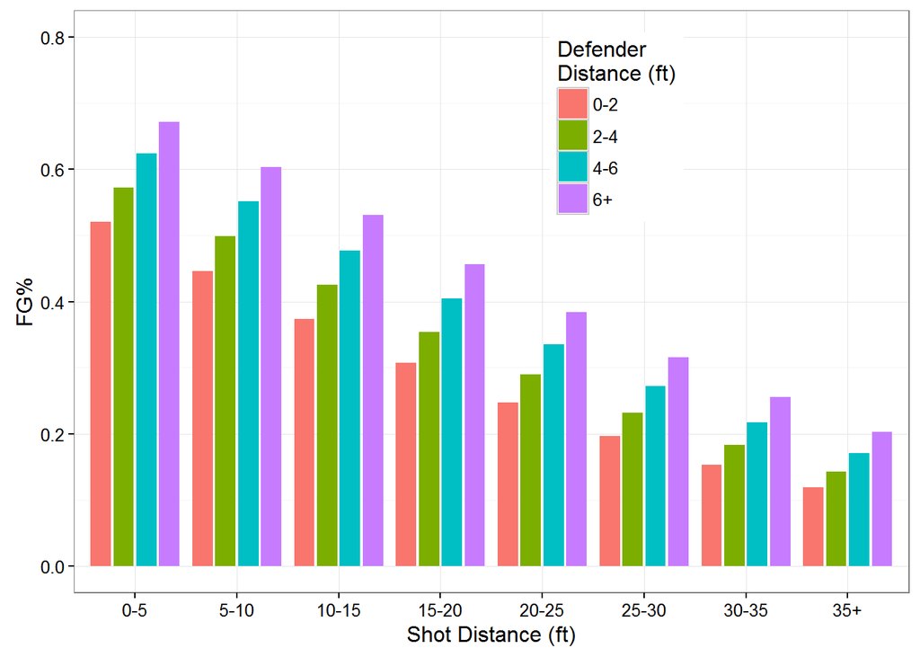

```r
shot.pred <- mutate(newdata, FG = FG)

ggplot(shot.pred, aes(x = factor(SHOT_DIST), y = FG, fill = factor(CLOSE_DEF_DIST))) +
  geom_bar(stat = "identity",  position = position_dodge(width = .9), width = 0.8) +
  ylab('FG%') + xlab('Shot Distance (ft)') + ylim(0, 0.8) +
  scale_x_discrete(labels=c('0-5', '5-10','10-15','15-20','20-25','25-30','30-35','35+'))+
  theme_bw(base_size = 12) +
  scale_fill_discrete(name="Defender\nDistance (ft)",
                      labels=c('0-2', '2-4','4-6','6+'))+
  theme(legend.position = c(0.65, 0.8))
```

Indeed, wide open shots in the paint have the highest probability and contested long 3s have the lowest. This plot conveys very similar information as the one I did in my shiny app. However, doing regression smoothens things out (regression to mean?) and losses some important features. For example, the predictions of extreme cases (shot distance < 5ft or > 35ft) are all less drastic than what the reality is. One way is that We can add higher order terms in the regression.

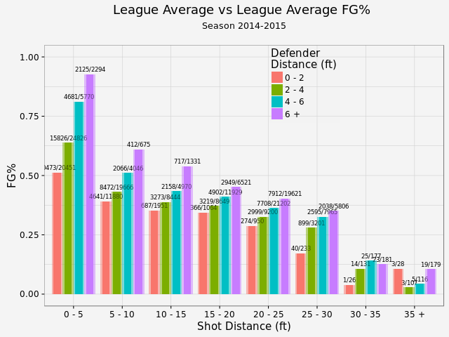

## Conclusion

There you have it, it is not that hard for ourselves to build a regression model from scratch (as we also demonstrated in [neural network](http://junma5.weebly.com/data-blog/build-your-own-neural-network-classifier-in-r)). If you follow this post, hopefully by now, you have a better understanding of logistic regression. One last note, although logistic regression is often said to be a classifier, it can also be used for regression (to find the probability).